# Machine Learning Project - Weight Lifting Prediction

Maja Nikolic

December 26, 2015

## Background

With the increased use of devices like Jawbone Up, Nike FuelBand, and Fitbit it became to easily and inexpensively collect a large amount of data about personal activity. Measurements are taken and recorded while performing various activities and can be later used for various experiments, project and analysis.

## Goal of the Project

Goal of this project is to use data from accelerometers on the belt, forearm, arm, and dumbell of 6 participants and predict the manner in which they did the exercise. They were asked to perform barbell lifts correctly and incorrectly in 5 different ways.  
The variable that needs to be predicted is the “classe” variable.

## Data Source

The data we used for this project can be found at HAR Web site: *http://groupware.les.inf.puc-rio.br/har*  
We downloaded both, training and testing data sets into corresponding data frames.  
All our algorithms and modifications will be done on the training data set - the testing data set will be used at the end to get the final evaluation of the model we selected.

```r
## Downloading the training and testing data sets
trainURL <- "https://d396qusza40orc.cloudfront.net/predmachlearn/pml-training.csv"
download.file(trainURL, destfile = "trainData.csv", method="curl")
trainingRaw <- read.csv("trainData.csv")

testURL <- "https://d396qusza40orc.cloudfront.net/predmachlearn/pml-testing.csv"
download.file(testURL, destfile = "testData.csv", method="curl")
testingRaw <- read.csv("testData.csv")
```

## Exploratory Data Analysis

Let’s take a look at some of the data before we start data clean-up and model selection.

```r
dimTrain <- dim(trainingRaw)
dimTest <- dim(testingRaw)
```

Training data set has 19622 rows and 160 columns.  
Testing data set has 20 rows and 160 columns.  
Although we did look into all columns of both datasets, since the number of columns is 160, we decided to display only a random sample of 8 columns:

```r
sampleCols <- sample(1:dimTrain[2],size=8,replace=FALSE)
str(trainingRaw[,sampleCols])
```

```
## 'data.frame':    19622 obs. of  8 variables:
##  $ avg_pitch_forearm   : num  NA NA NA NA NA NA NA NA NA NA ...
##  $ min_pitch_arm       : num  NA NA NA NA NA NA NA NA NA NA ...
##  $ accel_dumbbell_y    : int  47 47 46 48 48 48 47 46 47 48 ...
##  $ min_roll_belt       : num  NA NA NA NA NA NA NA NA NA NA ...
##  $ roll_belt           : num  1.41 1.41 1.42 1.48 1.48 1.45 1.42 1.42 1.43 1.45 ...
##  $ raw_timestamp_part_2: int  788290 808298 820366 120339 196328 304277 368296 440390 484323 484434 ...
##  $ accel_arm_x         : int  -288 -290 -289 -289 -289 -289 -289 -289 -288 -288 ...
##  $ avg_yaw_forearm     : num  NA NA NA NA NA NA NA NA NA NA ...
```

```r
summary(trainingRaw[,sampleCols])
```

```
##  avg_pitch_forearm min_pitch_arm     accel_dumbbell_y  min_roll_belt
##  Min.   :-68.17    Min.   :-180.00   Min.   :-189.00   Min.   :-180.00
##  1st Qu.:  0.00    1st Qu.: -72.62   1st Qu.:  -8.00   1st Qu.: -88.40
##  Median : 12.02    Median : -33.85   Median :  41.50   Median :  -7.85
##  Mean   : 11.79    Mean   : -33.92   Mean   :  52.63   Mean   : -10.44
##  3rd Qu.: 28.48    3rd Qu.:   0.00   3rd Qu.: 111.00   3rd Qu.:   9.05
##  Max.   : 72.09    Max.   : 152.00   Max.   : 315.00   Max.   : 173.00
##  NA's   :19216     NA's   :19216                       NA's   :19216
##    roll_belt      raw_timestamp_part_2  accel_arm_x      avg_yaw_forearm
##  Min.   :-28.90   Min.   :   294       Min.   :-404.00   Min.   :-155.06
##  1st Qu.:  1.10   1st Qu.:252912       1st Qu.:-242.00   1st Qu.: -26.26
##  Median :113.00   Median :496380       Median : -44.00   Median :   0.00
##  Mean   : 64.41   Mean   :500656       Mean   : -60.24   Mean   :  18.00
##  3rd Qu.:123.00   3rd Qu.:751891       3rd Qu.:  84.00   3rd Qu.:  85.79
##  Max.   :162.00   Max.   :998801       Max.   : 437.00   Max.   : 169.24
##                                                          NA's   :19216
```

Let’s also take a look at the variable we’re supposed to predict - *classe.*

```r
table(trainingRaw$classe)
```

```
##
##    A    B    C    D    E
## 5580 3797 3422 3216 3607
```

## Data Clean-up

As you can see from the previous section, there are 160 columns with too many of them containing a fair amount of NAs.  
We will first eliminate all columns that offer no variability, by using the *nearZeroVal* function from caret package.

```r
library(caret); library(kernlab)
nearZeroV <- nearZeroVar(trainingRaw,saveMetrics=FALSE)
trainingStep1 <- trainingRaw[,-nearZeroV]
dimStep1 <- dim(trainingStep1)
```

We eliminated 60 columns (that were adding no variability to the data set) and now we have 19622 rows and 100 columns.

Let’s take a look if there are any columns that are still candidates for elimination.  
We will eliminate another set of columns where more than 95% of rows/values are NAs.

```r
namesNAs <- names(which(colMeans(is.na(trainingStep1))>0.95))
colsNAs <- which(colnames(trainingStep1) %in% namesNAs)
trainingStep2 <- trainingStep1[,-colsNAs]
dimStep2 <- dim(trainingStep2)
```

We eliminated another 41 columns.

Since we were asked to predict classe variable based on belt, forearm, arm, and dumbell measurements, we will also eliminate timestamp and participant info factor variables:

```r
removeColNames <- c('X', 'user_name', 'raw_timestamp_part_1', 'raw_timestamp_part_2', 'cvtd_timestamp', 'new_window', 'num_window')
removeCols <- which(names(trainingStep2) %in% removeColNames)
trainingClean <- trainingStep2[, -removeCols]
dimClean <- dim(trainingClean)
```

Final version of the training set that we’ll try to find a predictive model for has 19622 rows and 53 columns.

## Cross-Validation

But, in order to somewhat test and compare different models, and since our data set has plenty of records, we will use cross-validation.

```r
set.seed(46864)
inTrain <- createDataPartition(y=trainingClean$classe, p=0.75, list=FALSE)
training <- trainingClean[inTrain,]
crossValidation <- trainingClean[-inTrain,]
```

## Prediction Models

We will try multiple predictive models and select, based on the results in the cross-validation data set, which on to use for the final prediction.

### Tree Model

First model we tried was the *Tree model*

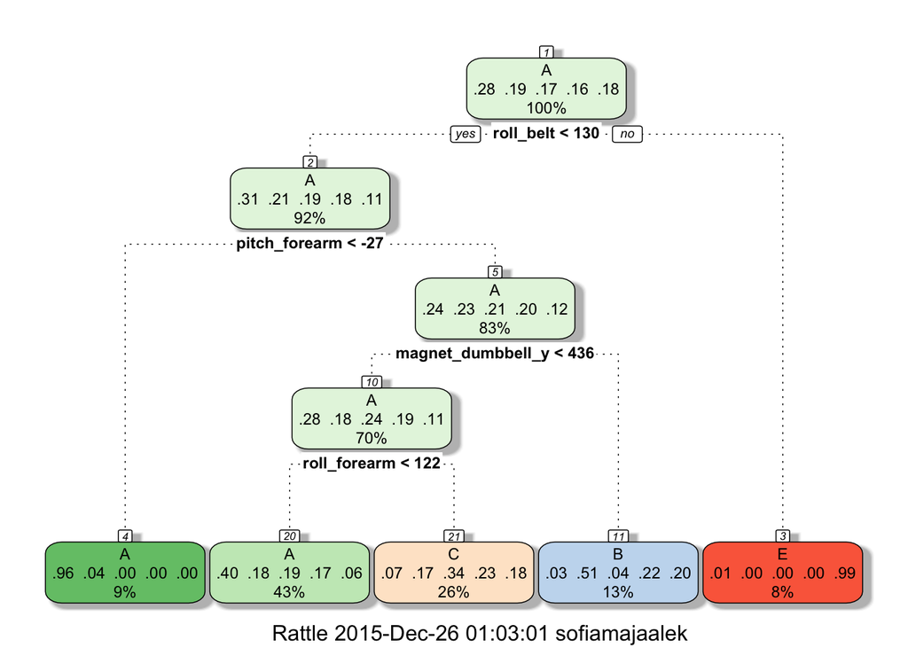

```r
modFitTR <- train(classe~., method="rpart", data=training)
library(rattle)
fancyRpartPlot(modFitTR$finalModel)
```

```r
crossValidatePredTR <- predict(modFitTR,newdata=crossValidation)
print(postResample(crossValidatePredTR, crossValidation$classe))
```

```
##  Accuracy     Kappa
## 0.4893964 0.3325241
```

### Random Forest

Second we’ll use Random Forest model with all varaibles in the data set we have.

```r
library(randomForest)
modFitRF <- randomForest(classe~., data=training, importance=TRUE, ntree=100)
print(modFitRF$confusion)
```

```
##      A    B    C    D    E  class.error
## A 4183    1    1    0    0 0.0004778973
## B   14 2828    6    0    0 0.0070224719
## C    0   19 2544    4    0 0.0089598753
## D    0    0   32 2377    3 0.0145107794
## E    0    0    2    8 2696 0.0036954915
```

```r
crossValidatePredRF <- predict(modFitRF, newdata = crossValidation)
print(postResample(crossValidatePredRF, crossValidation$classe))
```

```
##  Accuracy     Kappa
## 0.9971452 0.9963890
```

## Final Model Selection

As we can see from the 2 models prediction accuracies, Random Forest seems to be a better choice.  
We will use it to predict, for one time only, the values in the testing data set we downloaded at the beginning - testingRaw.  
We will apply the same transformations in the testing set as we did in the training set.  
We will also eliminate the last column - *problem_id*.

```r
testingStep1 <- testingRaw[,-nearZeroV]
testingStep2 <- testingStep1[,-colsNAs]
testingClean <- testingStep2[,-removeCols]
testingClean <- testingClean[, -which(names(testingClean)=="problem_id")]
testingPrediction <- predict(modFitRF, newdata=testingClean)
```

## Conclusion

Predictions we got from our Random Forest model are: **B, A, B, A, A, E, D, B, A, A, B, C, B, A, E, E, A, B, B, B**

## References

The data for this project was obtained from http://groupware.les.inf.puc-rio.br/har  
Velloso, E.; Bulling, A.; Gellersen, H.; Ugulino, W.; Fuks, H.  
Qualitative Activity Recognition of Weight Lifting Exercises.